# RMED901_Group1_Project_110923

## Reading, exploring and tidying data

### Importing packages

Assigning the dataset to an object “data”.

```r
library(tidyverse)
library(here)
library(GGally)
library(broom)

here()
```

```
## [1] "C:/Users/dux003/OneDrive - University of Bergen/PhD_FAG/RMED901/RMED901_Group1"
```

```r
data <- read_delim(here("Data", "exam_data.txt"))

data
```

```
## # A tibble: 387 × 14
##       id month  year   age `BMI kg/m2` Randomization `# attempts` `# failures`
##    <dbl> <dbl> <dbl> <dbl>       <dbl>         <dbl>        <dbl>        <dbl>
##  1     1     4  2012    51        56.2             0            1            0
##  2     1     4  2012    51        56.2             0            1            0
##  3     1     4  2012    51        56.2             0            1            0
##  4     2     7  2009    52        44.6             0            1            0
##  5     2     7  2009    52        44.6             0            1            0
##  6     2     7  2009    52        44.6             0            1            0
##  7     3    10  2012    37        41.6             0            2            1
##  8     3    10  2012    37        41.6             0            2            1
##  9     3    10  2012    37        41.6             0            2            1
## 10     4    11  2010    20        46.3             0            2            1
## # ℹ 377 more rows
## # ℹ 6 more variables: total_intubation_time <dbl>,
## #   intubation_overall_S_F <dbl>, view <dbl>,
## #   difficulties_intubating_feature <chr>, difficulties_intubating_value <dbl>,
## #   last_method_S_F <chr>
```

### Tidy dataset

We renamed columns, removed duplicates, created three new columns by pivoting wider, splitted a column into two columns and converted some columns that became character columns into numeric columns.

```r
tidy_data <- data %>% rename(BMI = "BMI kg/m2", # Renaming columns
                Attempts = "# attempts",
                Failures = "# failures") %>%
  distinct() %>% # Removing duplicates
  pivot_wider(names_from = difficulties_intubating_feature,
              values_from = difficulties_intubating_value) %>%  # Creating three new columns by pivoting wider
  separate(col = last_method_S_F,
           into = c("last_method", "last_method_S_F"),
           sep = "_") %>% # Splitting the last_method_S_F column into two different columns
  mutate(last_method_S_F = as.double(last_method_S_F),
         last_method = as.double(last_method)) # Converting these two columns to numeric columns as they were turned into character columns when splitting them

tidy_data
```

```
## # A tibble: 99 × 16
##       id month  year   age   BMI Randomization Attempts Failures
##    <dbl> <dbl> <dbl> <dbl> <dbl>         <dbl>    <dbl>    <dbl>
##  1     1     4  2012    51  56.2             0        1        0
##  2     2     7  2009    52  44.6             0        1        0
##  3     3    10  2012    37  41.6             0        2        1
##  4     4    11  2010    20  46.3             0        2        1
##  5     5     2  2009    35  61               0        1        0
##  6     6     1  2009    39  44               0        1        0
##  7     7     5  2012    52  44               0        1        0
##  8     8     7  2011    59  41.9             0        1        0
##  9     9     9  2010    32  47               0        1        0
## 10    10     3  2011    24  45               0        1        0
## # ℹ 89 more rows
## # ℹ 8 more variables: total_intubation_time <dbl>,
## #   intubation_overall_S_F <dbl>, view <dbl>, last_method <dbl>,
## #   last_method_S_F <dbl>, bleeding <dbl>, ease <dbl>, sore_throat <dbl>
```

## Tidying and exploring data

Removed the unnecessary rows “month” and “year”.

```r
data2 <- tidy_data %>% select(-c(month, year))

data2
```

```
## # A tibble: 99 × 14
##       id   age   BMI Randomization Attempts Failures total_intubation_time
##    <dbl> <dbl> <dbl>         <dbl>    <dbl>    <dbl>                 <dbl>
##  1     1    51  56.2             0        1        0                 29
##  2     2    52  44.6             0        1        0                 29
##  3     3    37  41.6             0        2        1                 91
##  4     4    20  46.3             0        2        1                 77
##  5     5    35  61               0        1        0                 21
##  6     6    39  44               0        1        0                 10
##  7     7    52  44               0        1        0                 13
##  8     8    59  41.9             0        1        0                 23
##  9     9    32  47               0        1        0                 15
## 10    10    24  45               0        1        0                  8.96
## # ℹ 89 more rows
## # ℹ 7 more variables: intubation_overall_S_F <dbl>, view <dbl>,
## #   last_method <dbl>, last_method_S_F <dbl>, bleeding <dbl>, ease <dbl>,
## #   sore_throat <dbl>
```

### Adding the additional dataset to our environment

Imported the additional dataset and assigned it to an object

```r
ad_df <- read_delim(here("Data", "exam_data_join.txt"))
ad_df
```

```
## # A tibble: 109 × 4
##       id gender   asa Mallampati
##    <dbl>  <dbl> <dbl>      <dbl>
##  1     1      0     3          1
##  2     2      0     3          2
##  3     3      0     3          1
##  4     4      0     3          2
##  5     5      0     3          2
##  6     6      0     3          2
##  7     7      0     3          2
##  8     8      0     3          2
##  9     9      0     3          1
## 10    10      0     3          1
## # ℹ 99 more rows
```

### Joining the two datasets

Deciding to join the original dataframe to the ad_df by the column “id” as this is present in both datasets. We have provided further explanations for each of the functions used inside the code-chunk.

```r
joined_df <- data2 %>%
  left_join(ad_df, by = "id") %>%
  distinct() %>% # Removing duplicates
 mutate(gender = if_else(gender == 0, "Female", "Male"), # Changing the column gender to show Female and Male
        Mallampati_asa = (asa*Mallampati), # Adding a column multiplicating the columns asa and Mallampati
        Ease_quartile = cut(ease, breaks = 4), # Creating a new column with quartile-values for the ease-column
        Method_check = if_else(last_method == Randomization, "True", "False")) %>%  # Creating a new column that checks whether the column "last method" contains the same values as the column "Randomization)

  select(id, gender, age, everything()) %>%  # Changing the order of the columns so that id, gender and age is at the beginning of the dataset.
  arrange(id) #%>%  # The id's in our dataset are already in increasing order

joined_df
```

```
## # A tibble: 99 × 20
##       id gender   age   BMI Randomization Attempts Failures
##    <dbl> <chr>  <dbl> <dbl>         <dbl>    <dbl>    <dbl>
##  1     1 Female    51  56.2             0        1        0
##  2     2 Female    52  44.6             0        1        0
##  3     3 Female    37  41.6             0        2        1
##  4     4 Female    20  46.3             0        2        1
##  5     5 Female    35  61               0        1        0
##  6     6 Female    39  44               0        1        0
##  7     7 Female    52  44               0        1        0
##  8     8 Female    59  41.9             0        1        0
##  9     9 Female    32  47               0        1        0
## 10    10 Female    24  45               0        1        0
## # ℹ 89 more rows
## # ℹ 13 more variables: total_intubation_time <dbl>,
## #   intubation_overall_S_F <dbl>, view <dbl>, last_method <dbl>,
## #   last_method_S_F <dbl>, bleeding <dbl>, ease <dbl>, sore_throat <dbl>,
## #   asa <dbl>, Mallampati <dbl>, Mallampati_asa <dbl>, Ease_quartile <fct>,
## #   Method_check <chr>
```

### Checking for missing values in the dataset.

There are 2 missing values for BMI, 1 for sore_throat, 1 for mallampati and 1 for mallampati_asa

```r
joined_df %>% summarise(across(everything(), ~sum(is.na(.))))
```

```
## # A tibble: 1 × 20
##      id gender   age   BMI Randomization Attempts Failures total_intubation_time
##   <int>  <int> <int> <int>         <int>    <int>    <int>                 <int>
## 1     0      0     0     2             0        0        0                     0
## # ℹ 12 more variables: intubation_overall_S_F <int>, view <int>,
## #   last_method <int>, last_method_S_F <int>, bleeding <int>, ease <int>,
## #   sore_throat <int>, asa <int>, Mallampati <int>, Mallampati_asa <int>,
## #   Ease_quartile <int>, Method_check <int>
```

### Stratifying the dataset for a categorical column

We chose the column gender and are reporting min, max, mean and sd of a numeric column (chose the column total_intubation_time)

```r
joined_df %>%
  group_by(gender) %>%
  summarise(
    min_total_intubation_time = min(total_intubation_time, na.rm = T),
    max_total_intubation_time = max(total_intubation_time, na.rm = T),
    mean_total_intubation_time = mean(total_intubation_time, na.rm = T),
    sd_total_intubation_time = sd(total_intubation_time, na.rm = T))
```

```
## # A tibble: 2 × 5
##   gender min_total_intubation_time max_total_intubation…¹ mean_total_intubatio…²
##   <chr>                      <dbl>                  <dbl>                  <dbl>
## 1 Female                      8.96                     98                   33.7
## 2 Male                       16.5                     100                   51.6
## # ℹ abbreviated names: ¹max_total_intubation_time, ²mean_total_intubation_time
## # ℹ 1 more variable: sd_total_intubation_time <dbl>
```

#### Only for persons with BMI <= 40

Reporting min, max, mean and sd.

```r
joined_df %>%
  group_by(gender) %>%
  filter(BMI <= 40) %>%
   summarise(
    min_total_intubation_time = min(total_intubation_time, na.rm = T),
    max_total_intubation_time = max(total_intubation_time, na.rm = T),
    mean_total_intubation_time = mean(total_intubation_time, na.rm = T),
    sd_total_intubation_time = sd(total_intubation_time, na.rm = T))
```

```
## # A tibble: 2 × 5
##   gender min_total_intubation_time max_total_intubation…¹ mean_total_intubatio…²
##   <chr>                      <dbl>                  <dbl>                  <dbl>
## 1 Female                        19                     90                   34.5
## 2 Male                          29                    100                   52
## # ℹ abbreviated names: ¹max_total_intubation_time, ²mean_total_intubation_time
## # ℹ 1 more variable: sd_total_intubation_time <dbl>
```

#### Only for females

Reporting min, max, mean and sd.

```r
joined_df %>%
  group_by(Randomization) %>%
  filter(gender == "Female") %>%
   summarise(
    min_total_intubation_time = min(total_intubation_time, na.rm = T),
    max_total_intubation_time = max(total_intubation_time, na.rm = T),
    mean_total_intubation_time = mean(total_intubation_time, na.rm = T),
    sd_total_intubation_time = sd(total_intubation_time, na.rm = T))
```

```
## # A tibble: 2 × 5
##   Randomization min_total_intubation_time max_total_intubation_time
##           <dbl>                     <dbl>                     <dbl>
## 1             0                      8.96                        91
## 2             1                     12.4                         98
## # ℹ 2 more variables: mean_total_intubation_time <dbl>,
## #   sd_total_intubation_time <dbl>
```

#### Only for those above the age of 45

Reporting min, max, mean and sd.

```r
joined_df %>%
  group_by(Attempts) %>%
  filter(age > 45) %>%
   summarise(
    min_total_intubation_time = min(total_intubation_time, na.rm = T),
    max_total_intubation_time = max(total_intubation_time, na.rm = T),
    mean_total_intubation_time = mean(total_intubation_time, na.rm = T),
    sd_total_intubation_time = sd(total_intubation_time, na.rm = T))
```

```
## # A tibble: 3 × 5
##   Attempts min_total_intubation_…¹ max_total_intubation…² mean_total_intubatio…³
##      <dbl>                   <dbl>                  <dbl>                  <dbl>
## 1        1                    12.4                    100                   36.1
## 2        2                    37                       90                   70
## 3        3                    98                       98                   98
## # ℹ abbreviated names: ¹min_total_intubation_time, ²max_total_intubation_time,
## #   ³mean_total_intubation_time
## # ℹ 1 more variable: sd_total_intubation_time <dbl>
```

#### Only for those with mallampati score above or equal to 2

Reporting min, max, mean and sd

```r
joined_df %>%
  group_by(Failures) %>%
  filter(Mallampati >= 2) %>%
   summarise(
    min_total_intubation_time = min(total_intubation_time, na.rm = T),
    max_total_intubation_time = max(total_intubation_time, na.rm = T),
    mean_total_intubation_time = mean(total_intubation_time, na.rm = T),
    sd_total_intubation_time = sd(total_intubation_time, na.rm = T))
```

```
## # A tibble: 3 × 5
##   Failures min_total_intubation_…¹ max_total_intubation…² mean_total_intubatio…³
##      <dbl>                   <dbl>                  <dbl>                  <dbl>
## 1        0                      10                    100                   33.1
## 2        1                      37                     80                   64.7
## 3        2                     100                    100                  100
## # ℹ abbreviated names: ¹min_total_intubation_time, ²max_total_intubation_time,
## #   ³mean_total_intubation_time
## # ℹ 1 more variable: sd_total_intubation_time <dbl>
```

### Used two categorical columns in our dataset to create a table.

Decided to choose gender and attempts.

```r
CC_table <- joined_df %>%
  count(gender, Attempts)

CC_table
```

```
## # A tibble: 6 × 3
##   gender Attempts     n
##   <chr>     <dbl> <int>
## 1 Female        1    74
## 2 Female        2     3
## 3 Female        3     1
## 4 Male          1    15
## 5 Male          2     4
## 6 Male          3     2
```

## Data analysis

### Correlated measurements

Creating a heat map to compare all variables and see trends of correlations. Note that the non-numeric columns gender, Ease_quartile and Method_check are not included in the heat map. We see that id is positively correlated with randomization and last_method as well as failures with attempts and intubation time, and attempts and intubation time. Intubation_overall_S_F is negatively correlated with bleed, ease, sore throat, total_intubation_time, failures, attempts. View and ease are also negatively correlated.

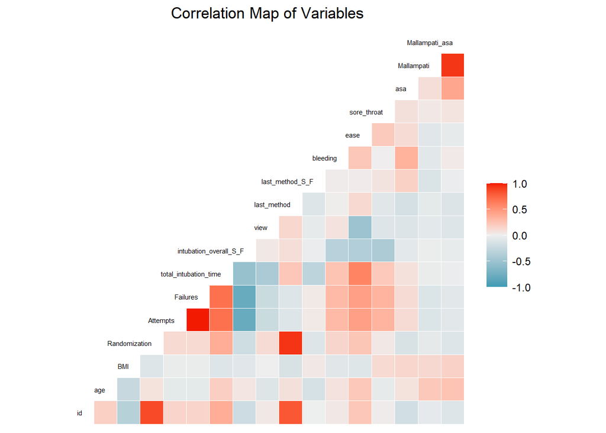

```r
joined_df %>%
  ggcorr(label = F, label_size = 3, label_round = 2,
            label_alpha = TRUE, hjust = 1, size = 2) + # Moved the column labels
labs(title="Correlation Map of Variables") +
  theme(plot.title = element_text(hjust =0.5 )) # Adds a title centered in the middle
```

### Checking if age distribution depends on gender:

Made a density plot of the age distribution depending on gender. We removed the grey background and the major and minor grids. We set the colour of the axis to black. We set the x-axis limit from 20 to 80.

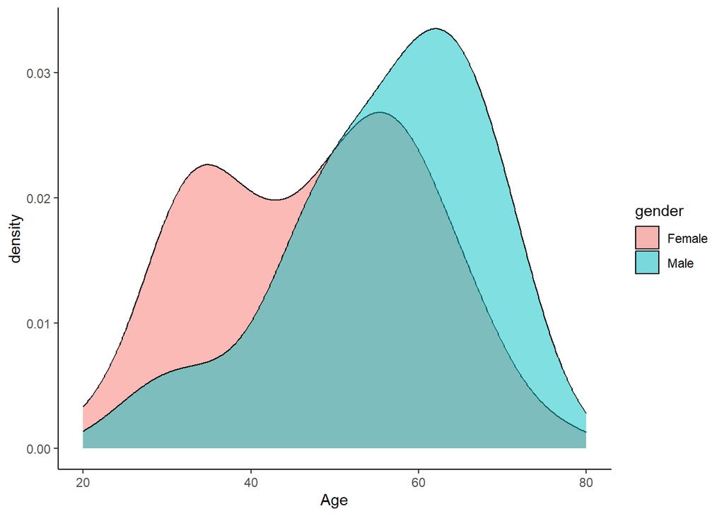

```r
joined_df %>%
  ggplot(aes(x = age, fill = gender)) + geom_density(alpha = 0.5) +
  theme(panel.grid.major = element_blank(),
        panel.grid.minor = element_blank(),
panel.background = element_blank(), axis.line = element_line(colour = "black")) +
  scale_x_continuous(name = "Age",limits = c(20,80))
```

### Checking if age and BMI have a linear relationship

Checking if age and BMI have a linear relationship by adding geom_smooth (adds a regression line with confidence intervals) to a scatterplot. Also removed the grey background and the grids. We set the x-asis limit from 20 to 80. The BMI is slightly depended on age, where BMI is at its highest around 20 years of age, and it slightly decreases as age increases. The correlation is therefore negative.

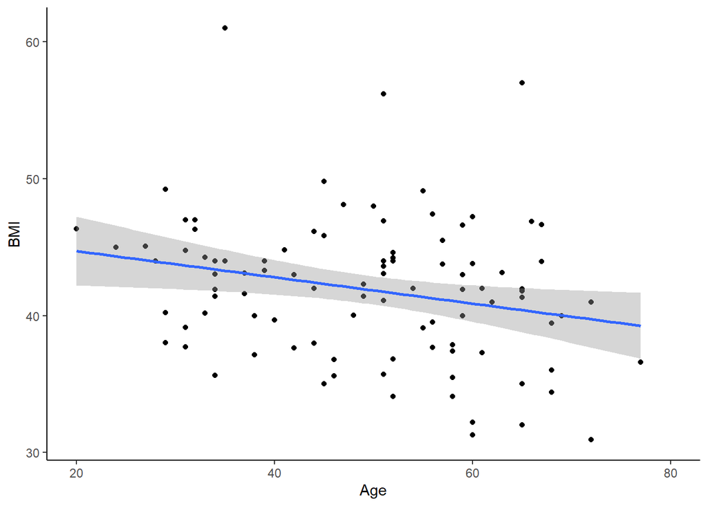

```r
joined_df %>%
  ggplot(aes(x = age, y = BMI)) +
  geom_point(na.rm = T) +
  geom_smooth(method = "lm", na.rm = T) +
  theme(panel.grid.major = element_blank(),
        panel.grid.minor = element_blank(),
        panel.background = element_blank(),
        axis.line = element_line(colour = "black")) +
  scale_x_continuous(name = "Age",limits = c(20,80))
```

### Does number of failures change with age

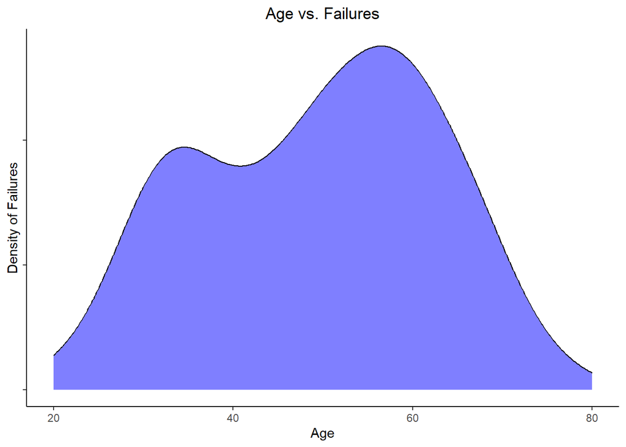

```r
joined_df %>%
  ggplot(aes(x = age, fill = Failures)) +
  geom_density(alpha = 0.5,fill= "blue") + # Made the area under the curve blue
  labs(title = "Age vs. Failures") +
  ylab("Density of Failures") +
  theme(plot.title = element_text(hjust = 0.5 ),
        axis.text.y = element_blank()
        ) +
  scale_x_continuous(name = "Age", limits = c(20,80)) +
  theme(panel.grid.major = element_blank(),
        panel.grid.minor = element_blank(),
        panel.background = element_blank(),
        axis.line = element_line(colour = "black")
  )
```

### Checking if randomization is dependent on gender

Performed a t-test which returned a p-value of 0.8 and therefore is not statistically significant.

```r
joined_df %>% t.test(Randomization~gender, data = .)
```

```
##
##  Welch Two Sample t-test
##
## data:  Randomization by gender
## t = -0.18991, df = 31.219, p-value = 0.8506
## alternative hypothesis: true difference in means between group Female and group Male is not equal to 0
## 95 percent confidence interval:
##  -0.2794369  0.2318178
## sample estimates:
## mean in group Female   mean in group Male
##            0.5000000            0.5238095
```

### Checking if randomization dependent on BMI

We chose to use an anova test. This showed that the p-value was not statistically significant.

```r
anova_r_BMI <- joined_df %>% aov(Randomization~BMI, data = .)

anova_r_BMI %>% tidy()
```

```
## # A tibble: 2 × 6
##   term         df  sumsq meansq statistic p.value
##   <chr>     <dbl>  <dbl>  <dbl>     <dbl>   <dbl>
## 1 BMI           1  0.264  0.264      1.05   0.309
## 2 Residuals    95 24.0    0.252     NA     NA
```

### Checking if there is an association between BMI and total intubation time

Used a scatterplot with a fitted regression line which is showing that there is no clear linear association.

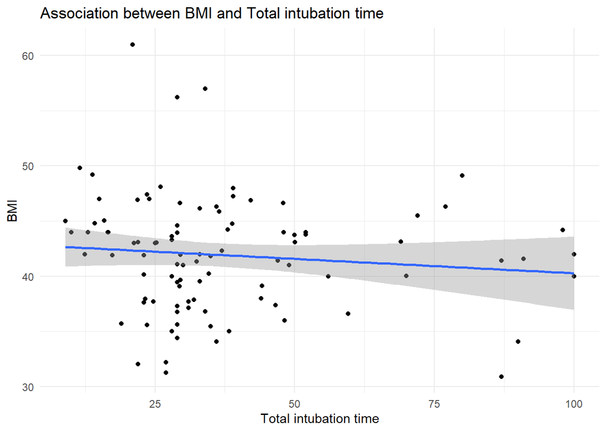

```r
joined_df %>% ggplot(aes(x = total_intubation_time, y = BMI)) +
  geom_point(na.rm = T) +
  geom_smooth(method = "lm", na.rm = T) +
  labs(x="Total intubation time") +
  theme_minimal() +
  labs(title = "Association between BMI and Total intubation time")
```

### Comparing Total Intubation time by Gender

Making a box plot to compare the two gender categories. The plot highlights that on average, patients in the “Female” category had a shorter overall intubation time than patients in the “Male” category, save for some outliers in the “Female” category.

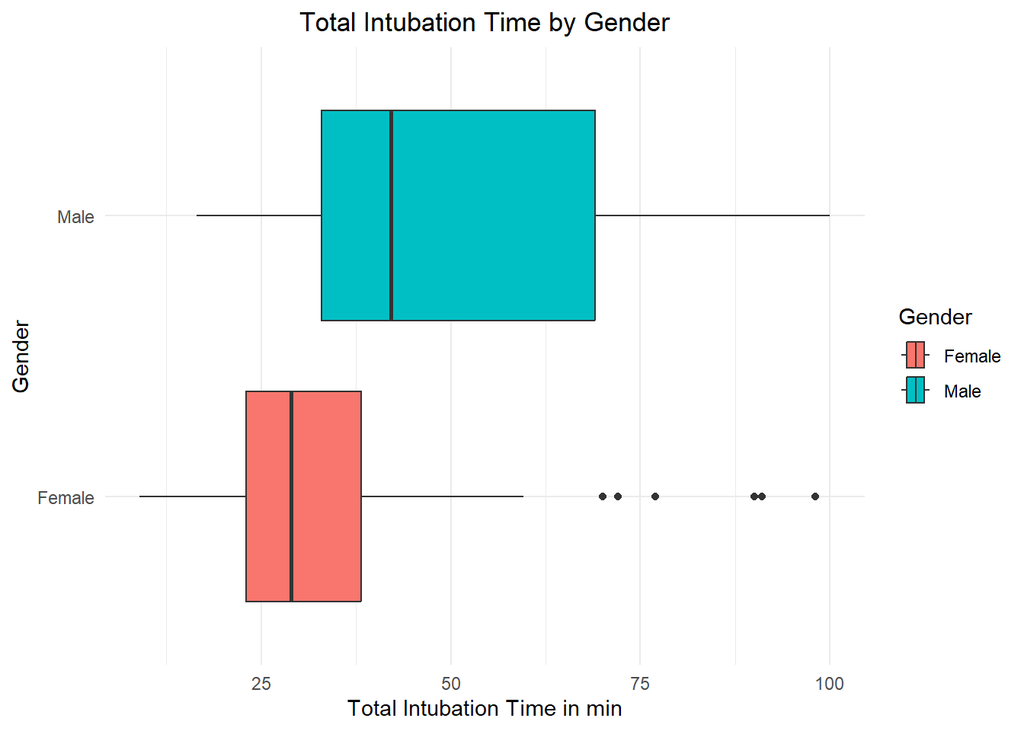

```r
ggplot(joined_df, aes(y=gender, x=total_intubation_time, fill=gender)) +
  geom_boxplot() +
labs(x="Total Intubation Time in min", y="Gender", fill="Gender") +
  theme_minimal() +
  labs(title = "Total Intubation Time by Gender") +
  theme(plot.title = element_text(hjust =0.5 )) # Layout design for the plot
```